# Review3 - Exploratory Data Analysis on Zomato Restaurants present in India

### Reg. No: 18BCE1090

### Name: DISHANTH G

## Setup

```r
library(knitr)
library(kableExtra)
library(dplyr)
```

```r
library(ggplot2)
```

## **What problem are you trying to solve?**

### With this exploratory data analysis, upcoming startup restaurants which have an idea to partner with zomato can be aware of the factors that affect their business and also the improvements existing restaurants can make from the analysis.

### Some of the factors we will analyze are restaurant Location,Establishment,Cuisine Type,price range,reviews,customer votes,delivery and takeaway options.

### To find people’s major favourite cuisines,taste and how it is differing from city to city.

## **What data have you chosen?(Chosen Dataset, Source of dataset, Description of dataset, basic commands to describe dataset)**

### **Chosen Dataset**:Zomato Restaurants in India

### **Source of Dataset**:From Kaggle

### **Description of the dataset**:The dataset was taken from zomato API in JSON/XML format and has been published in Kaggle as a CSV file.The dataset consist of restaurants present in major cities of India along with details like Location address,cusines types,timings,average cost for 2 people,ratings,votes and delivery options.

### **Basic Commands**:

#### **(i)Load Data**:

```r
df=read.csv("zomato_restaurants_in_India.csv")
```

#### **(ii)First 3 rows of the dataset**:

```r
kable(head(df,3), "html") %>% kable_styling("striped") %>% scroll_box(width = "100%")
```

| res_id | name | establishment | url | address | city | city_id | locality | latitude | longitude | zipcode | country_id | locality_verbose | cuisines | timings | average_cost_for_two | price_range | currency | highlights | aggregate_rating | rating_text | votes | photo_count | opentable_support | delivery | takeaway |
| --- | --- | --- | --- | --- | --- | --- | --- | --- | --- | --- | --- | --- | --- | --- | --- | --- | --- | --- | --- | --- | --- | --- | --- | --- | --- |
| 3400299 | Bikanervala | [‘Quick Bites’] | https://www.zomato.com/agra/bikanervala-khandari?utm_source=api_basic_user&utm_medium=api&utm_campaign=v2.1 | Kalyani Point, Near Tulsi Cinema, Bypass Road, Khandari, Agra | Agra | 34 | Khandari | 27.21145 | 78.00238 |  | 1 | Khandari, Agra | North Indian, South Indian, Mithai, Street Food, Desserts | 8:30am â€“ 10:30pm (Mon-Sun) | 700 | 2 | Rs. | [‘Lunch’, ‘Takeaway Available’, ‘Credit Card’, ‘Dinner’, ‘Cash’, ‘Air Conditioned’, ‘Indoor Seating’, ‘Pure Veg’] | 4.4 | Very Good | 814 | 154 | 0 | -1 | -1 |
| 3400005 | Mama Chicken Mama Franky House | [‘Quick Bites’] | https://www.zomato.com/agra/mama-chicken-mama-franky-house-agra-cantt?utm_source=api_basic_user&utm_medium=api&utm_campaign=v2.1 | Main Market, Sadar Bazaar, Agra Cantt, Agra | Agra | 34 | Agra Cantt | 27.16057 | 78.01158 | 282001 | 1 | Agra Cantt, Agra | North Indian, Mughlai, Rolls, Chinese, Fast Food, Street Food | 12:30PM to 12Midnight (Mon, Wed, Thu, Fri, Sat, Sun), 1PM to 12Midnight (Tue) | 600 | 2 | Rs. | [‘Delivery’, ‘No Alcohol Available’, ‘Dinner’, ‘Takeaway Available’, ‘Lunch’, ‘Cash’, ‘Indoor Seating’] | 4.4 | Very Good | 1203 | 161 | 0 | -1 | -1 |
| 3401013 | Bhagat Halwai | [‘Quick Bites’] | https://www.zomato.com/agra/bhagat-halwai-2-shahganj?utm_source=api_basic_user&utm_medium=api&utm_campaign=v2.1 | 62/1, Near Easy Day, West Shivaji Nagar, Goalpura, Shahganj | Agra | 34 | Shahganj | 27.18294 | 77.97968 | 282010 | 1 | Shahganj, Agra | Fast Food, Mithai | 9:30 AM to 11 PM | 300 | 1 | Rs. | [‘No Alcohol Available’, ‘Dinner’, ‘Takeaway Available’, ‘Breakfast’, ‘Lunch’, ‘Cash’, ‘Delivery’, ‘Outdoor Seating’, ‘Air Conditioned’, ‘Self Service’, ‘Indoor Seating’, ‘Digital Payments Accepted’, … | 4.2 | Very Good | 801 | 107 | 0 | 1 | -1 |

#### **(iii)Column names present in the dataset**:

```r
colnames(df)
```

```
##  [1] "res_id"               "name"                 "establishment"
##  [4] "url"                  "address"              "city"
##  [7] "city_id"              "locality"             "latitude"
## [10] "longitude"            "zipcode"              "country_id"
## [13] "locality_verbose"     "cuisines"             "timings"
## [16] "average_cost_for_two" "price_range"          "currency"
## [19] "highlights"           "aggregate_rating"     "rating_text"
## [22] "votes"                "photo_count"          "opentable_support"
## [25] "delivery"             "takeaway"
```

#### **(iv)Structure of the data which gives each columns data type along with number of observation and variables present**:

```r
str(df)
```

```
## 'data.frame':    211944 obs. of  26 variables:
##  $ res_id              : int  3400299 3400005 3401013 3400290 3401744 3400275 3400296 3400368 3401284 3400838 ...
##  $ name                : chr  "Bikanervala" "Mama Chicken Mama Franky House" "Bhagat Halwai" "Bhagat Halwai" ...
##  $ establishment       : chr  "['Quick Bites']" "['Quick Bites']" "['Quick Bites']" "['Quick Bites']" ...
##  $ url                 : chr  "https://www.zomato.com/agra/bikanervala-khandari?utm_source=api_basic_user&utm_medium=api&utm_campaign=v2.1" "https://www.zomato.com/agra/mama-chicken-mama-franky-house-agra-cantt?utm_source=api_basic_user&utm_medium=api&"| __truncated__ "https://www.zomato.com/agra…
##  $ address             : chr  "Kalyani Point, Near Tulsi Cinema, Bypass Road, Khandari, Agra" "Main Market, Sadar Bazaar, Agra Cantt, Agra" "62/1, Near Easy Day, West Shivaji Nagar, Goalpura, Shahganj" "Near Anjana Cinema, Nehru Nagar, Civil Lines, Agra" ...
##  $ city                : chr  "Agra" "Agra" "Agra" "Agra" ...
##  $ city_id             : int  34 34 34 34 34 34 34 34 34 34 ...
##  $ locality            : chr  "Khandari" "Agra Cantt" "Shahganj" "Civil Lines" ...
##  $ latitude            : num  27.2 27.2 27.2 27.2 27.2 ...
##  $ longitude           : num  78 78 78 78 78.1 ...
##  $ zipcode             : chr  "" "282001" "282010" "282002" ...
##  $ country_id          : int  1 1 1 1 1 1 1 1 1 1 ...
##  $ locality_verbose    : chr  "Khandari, Agra" "Agra Cantt, Agra" "Shahganj, Agra" "Civil Lines, Agra" ...
##  $ cuisines            : chr  "North Indian, South Indian, Mithai, Street Food, Desserts" "North Indian, Mughlai, Rolls, Chinese, Fast Food, Street Food" "Fast Food, Mithai" "Desserts, Bakery, Fast Food, South Indian" ...
##  $ timings             : chr  "8:30am â\200“ 10:30pm (Mon-Sun)" "12:30PM to 12Midnight (Mon, Wed, Thu, Fri, Sat, Sun), 1PM to 12Midnight (Tue)" "9:30 AM to 11 PM" "8am â\200“ 11pm (Mon-Sun)" ...
##  $ average_cost_for_two: int  700 600 300 300 1000 400 500 400 500 1000 ...
##  $ price_range         : int  2 2 1 1 3 2 2 2 2 3 ...
##  $ currency            : chr  "Rs." "Rs." "Rs." "Rs." ...
##  $ highlights          : chr  "['Lunch', 'Takeaway Available', 'Credit Card', 'Dinner', 'Cash', 'Air Conditioned', 'Indoor Seating', 'Pure Veg']" "['Delivery', 'No Alcohol Available', 'Dinner', 'Takeaway Available', 'Lunch', 'Cash', 'Indoor Seating']" "['No Alcohol Available', 'Dinner', 'Takeaway…
##  $ aggregate_rating    : num  4.4 4.4 4.2 4.3 4.9 4 4.2 3.8 3.4 4.4 ...
##  $ rating_text         : chr  "Very Good" "Very Good" "Very Good" "Very Good" ...
##  $ votes               : int  814 1203 801 693 470 707 647 617 322 289 ...
##  $ photo_count         : int  154 161 107 157 291 62 46 18 14 324 ...
##  $ opentable_support   : int  0 0 0 0 0 0 0 0 0 0 ...
##  $ delivery            : int  -1 -1 1 1 1 -1 1 -1 1 1 ...
##  $ takeaway            : int  -1 -1 -1 -1 -1 -1 -1 -1 -1 -1 ...
```

#### **(v)Summary Statistics of the dataset**:

```r
summary(df)
```

```
##      res_id             name           establishment          url
##  Min.   :      50   Length:211944      Length:211944      Length:211944
##  1st Qu.: 3301027   Class :character   Class :character   Class :character
##  Median :18695734   Mode  :character   Mode  :character   Mode  :character
##  Mean   :13494112
##  3rd Qu.:18812974
##  Max.   :19159790
##
##    address              city              city_id        locality
##  Length:211944      Length:211944      Min.   :    1   Length:211944
##  Class :character   Class :character   1st Qu.:   11   Class :character
##  Mode  :character   Mode  :character   Median :   34   Mode  :character
##                                        Mean   : 4747
##                                        3rd Qu.:11306
##                                        Max.   :11354
##
##     latitude          longitude       zipcode            country_id
##  Min.   :    0.00   Min.   : 0.00   Length:211944      Min.   :1
##  1st Qu.:   15.50   1st Qu.:74.88   Class :character   1st Qu.:1
##  Median :   22.51   Median :77.43   Mode  :character   Median :1
##  Mean   :   21.50   Mean   :77.62                      Mean   :1
##  3rd Qu.:   26.84   3rd Qu.:80.22                      3rd Qu.:1
##  Max.   :10000.00   Max.   :91.83                      Max.   :1
##
##  locality_verbose     cuisines           timings          average_cost_for_two
##  Length:211944      Length:211944      Length:211944      Min.   :    0.0
##  Class :character   Class :character   Class :character   1st Qu.:  250.0
##  Mode  :character   Mode  :character   Mode  :character   Median :  400.0
##                                                           Mean   :  595.8
##                                                           3rd Qu.:  700.0
##                                                           Max.   :30000.0
##
##   price_range      currency          highlights        aggregate_rating
##  Min.   :1.000   Length:211944      Length:211944      Min.   :0.000
##  1st Qu.:1.000   Class :character   Class :character   1st Qu.:3.300
##  Median :2.000   Mode  :character   Mode  :character   Median :3.800
##  Mean   :1.883                                         Mean   :3.396
##  3rd Qu.:2.000                                         3rd Qu.:4.100
##  Max.   :4.000                                         Max.   :4.900
##
##  rating_text            votes        photo_count    opentable_support
##  Length:211944      Min.   :  -18   Min.   :    0   Min.   :0
##  Class :character   1st Qu.:   16   1st Qu.:    3   1st Qu.:0
##  Mode  :character   Median :  100   Median :   18   Median :0
##                     Mean   :  378   Mean   :  257   Mean   :0
##                     3rd Qu.:  362   3rd Qu.:  128   3rd Qu.:0
##                     Max.   :42539   Max.   :17702   Max.   :0
##                                                     NA's   :48
##     delivery          takeaway
##  Min.   :-1.0000   Min.   :-1
##  1st Qu.:-1.0000   1st Qu.:-1
##  Median :-1.0000   Median :-1
##  Mean   :-0.2559   Mean   :-1
##  3rd Qu.: 1.0000   3rd Qu.:-1
##  Max.   : 1.0000   Max.   :-1
##
```

#### **(vi)Dimensions of the dataset**:

```r
dim(df)
```

```
## [1] 211944     26
```

## **Objectives**:

### 1.Cleaning and preprocessing the data to make it ready for Exploratory Data Analysis.

### 2.Analysing the restaurants based on numerous factors like establishments,locality,cusine types,timings,price range,ratings,votes,delivery options.

- Univariate Analysis on Overall Dataset
- Geo-Spatial Analysis on India.
- Univariate and Bivariate Analysis on Chennai and its locality
- Univariate Analysis on Mumbai
- Bivariate Analysis on top 10 cities of india.

### 3.Comparing customer’s favourite cuisine type that are present among different cities.

### 4.Finding the price range that is suitable for customers among different cities.

### 5.Analysing the same restaurant’s branch present in different locality and determining the quality among them with the help of customer ratings.

### 6.Doing inferential statistics with the data(ANOVA TEST,Correlation test)

### 7.Also predicting whether a new restaurant can be successfull on partnering with zomato using Machine Learning models(i.e)to predict the suitable cost of the new restaurant based on the various factors

## **Is there any work previously reported on the problem and the data? If so, discuss it here.**

### ANSWER:There is only one analysis done before on the dataset I have selected and it is a very brief analysis on taking only a small subset of the dataset.The person has selected restaurants present only in Bangalore City and has found the major restaurant establishments present,Localities with the maximum number of restaurant in Bangalore.

## **Cleaning the dataset**

### Removing duplicate data and columns that are not useful for Analysis

```r
df1=df[,-c(1,4,5,7,11,12,13,15,18)]
df1=unique(df1)
```

#### Here we removed restaurant id,restaurant url details,restaurant address,city id,zipcode,country id,locality verbose,currency

### Establishment Column

```r
df1%>%
distinct(establishment)
```

```
##          establishment
## 1      ['Quick Bites']
## 2    ['Casual Dining']
## 3           ['Bakery']
## 4            ['CafÃ©']
## 5            ['Dhaba']
## 6       ['Bhojanalya']
## 7              ['Bar']
## 8       ['Sweet Shop']
## 9      ['Fine Dining']
## 10      ['Food Truck']
## 11 ['Dessert Parlour']
## 12          ['Lounge']
## 13             ['Pub']
## 14   ['Beverage Shop']
## 15           ['Kiosk']
## 16       ['Paan Shop']
## 17   ['Confectionery']
## 18                  []
## 19           ['Shack']
## 20            ['Club']
## 21      ['Food Court']
## 22            ['Mess']
## 23    ['Butcher Shop']
## 24    ['Microbrewery']
## 25    ['Cocktail Bar']
## 26          ['Pop up']
## 27      ['Irani Cafe']
```

```r
df1%>%
  summarise(ctnmiss=sum(is.na(establishment)))
```

```
##   ctnmiss
## 1       0
```

```r
df1=df1%>%
  mutate(establishment=gsub("\\[|\\]", "", establishment))

df1=df1%>%
  mutate(establishment=gsub("'", "", establishment))

df1=df1%>%
  mutate(establishment=gsub("Ã©", "e", establishment))

df1=df1%>%
  mutate(establishment=replace(establishment,establishment=="","Not Mentioned"))

df1%>%
  distinct(establishment)
```

```
##      establishment
## 1      Quick Bites
## 2    Casual Dining
## 3           Bakery
## 4             Cafe
## 5            Dhaba
## 6       Bhojanalya
## 7              Bar
## 8       Sweet Shop
## 9      Fine Dining
## 10      Food Truck
## 11 Dessert Parlour
## 12          Lounge
## 13             Pub
## 14   Beverage Shop
## 15           Kiosk
## 16       Paan Shop
## 17   Confectionery
## 18   Not Mentioned
## 19           Shack
## 20            Club
## 21      Food Court
## 22            Mess
## 23    Butcher Shop
## 24    Microbrewery
## 25    Cocktail Bar
## 26          Pop up
## 27      Irani Cafe
```

#### There are 27 establishment type present in india.Here we find that there is no missing data but there are empty strings present which we replace to “Not Mentioned” and we can remove the brackets,special characters and quotation marks present.

### Cuisine

```r
#df1%>%
 # distinct(cuisines)

#df1%>%
 # filter(cuisines=="")

df1%>%
  summarise(ctnmiss=sum(is.na(cuisines)))
```

```
##   ctnmiss
## 1       0
```

```r
df1=df1%>%
  mutate(cuisines=replace(cuisines,cuisines=="","Not Given"))
```

#### There are no missing values but there are empty string so we replace it to "“Not given”

### Average cost for two

```r
#df1%>%
 # distinct(average_cost_for_two)


table(df1$average_cost_for_two)
```

```
##
##     0     2    15    20    30    35    40    45    50    60    70    75    80
##   825     1     1     4     3     2     7     1   315    41    11     2    38
##    90   100   110   115   120   125   130   140   149   150   160   170   175
##     3  4755     2     1    72     1     2     4     1  4059     8     1     2
##   180   190   197   200   208   220   240   250   260   280   282   294   299
##    17     3     1  7051     2     5     4  3749     2     3     1     1     1
##   300   309   312   320   330   350   360   380   400   404   420   440   444
##  6961     1     1     1     1  2139     2     1  5678     1     1     1     1
##   445   450   470   500   505   520   550   592   600   620   640   650   700
##     1  1362     1  5267     1     1   576     1  3040     1     1   584  1850
##   750   800   850   880   900   940   950   999  1000  1020  1050  1100  1150
##   359  2173   198     1   578     1    49     1  1802     1     9   323     6
##  1190  1200  1230  1250  1260  1300  1350  1400  1450  1499  1500  1550  1600
##     1  1141     1    29     1   373    14   448     5     1  1211     6   474
##  1650  1700  1750  1800  1850  1875  1900  1950  2000  2100  2200  2250  2300
##    10   207     4   361     8     1   105     2   675    72   141     2    49
##  2400  2500  2501  2600  2700  2800  2900  3000  3100  3200  3250  3300  3400
##    61   296     1    48    26    22     5   231     4    16     1     4     6
##  3500  3600  3650  3700  3800  3900  4000  4050  4100  4200  4300  4500  4600
##    86    10     1     6     7     2    91     1     2    14     3    42     1
##  4800  5000  5100  5500  6000  6500  6600  7000  7500  8000 10000 12000 14000
##     3    52     1    14    13     3     1     3     1     5     1     3     1
## 15000 30000
##     2     1
```

```r
df1%>%
  summarise(ctnmiss=sum(is.na(average_cost_for_two)))
```

```
##   ctnmiss
## 1       0
```

```r
class(df1$average_cost_for_two)
```

```
## [1] "integer"
```

```r
#remove rows having average cost as 0
df1=df1%>%
  filter(average_cost_for_two!=0)



table(df1$average_cost_for_two)
```

```
##
##     2    15    20    30    35    40    45    50    60    70    75    80    90
##     1     1     4     3     2     7     1   315    41    11     2    38     3
##   100   110   115   120   125   130   140   149   150   160   170   175   180
##  4755     2     1    72     1     2     4     1  4059     8     1     2    17
##   190   197   200   208   220   240   250   260   280   282   294   299   300
##     3     1  7051     2     5     4  3749     2     3     1     1     1  6961
##   309   312   320   330   350   360   380   400   404   420   440   444   445
##     1     1     1     1  2139     2     1  5678     1     1     1     1     1
##   450   470   500   505   520   550   592   600   620   640   650   700   750
##  1362     1  5267     1     1   576     1  3040     1     1   584  1850   359
##   800   850   880   900   940   950   999  1000  1020  1050  1100  1150  1190
##  2173   198     1   578     1    49     1  1802     1     9   323     6     1
##  1200  1230  1250  1260  1300  1350  1400  1450  1499  1500  1550  1600  1650
##  1141     1    29     1   373    14   448     5     1  1211     6   474    10
##  1700  1750  1800  1850  1875  1900  1950  2000  2100  2200  2250  2300  2400
##   207     4   361     8     1   105     2   675    72   141     2    49    61
##  2500  2501  2600  2700  2800  2900  3000  3100  3200  3250  3300  3400  3500
##   296     1    48    26    22     5   231     4    16     1     4     6    86
##  3600  3650  3700  3800  3900  4000  4050  4100  4200  4300  4500  4600  4800
##    10     1     6     7     2    91     1     2    14     3    42     1     3
##  5000  5100  5500  6000  6500  6600  7000  7500  8000 10000 12000 14000 15000
##    52     1    14    13     3     1     3     1     5     1     3     1     2
## 30000
##     1
```

#### There are some restaurants having average cost as 0 which is not useful for analysis.So we can remove these restaurants.

### Highlights

```r
a=df1%>%
  select(highlights)
a[c(1:3),]
```

```
## [1] "['Lunch', 'Takeaway Available', 'Credit Card', 'Dinner', 'Cash', 'Air Conditioned', 'Indoor Seating', 'Pure Veg']"
## [2] "['Delivery', 'No Alcohol Available', 'Dinner', 'Takeaway Available', 'Lunch', 'Cash', 'Indoor Seating']"
## [3] "['No Alcohol Available', 'Dinner', 'Takeaway Available', 'Breakfast', 'Lunch', 'Cash', 'Delivery', 'Outdoor Seating', 'Air Conditioned', 'Self Service', 'Indoor Seating', 'Digital Payments Accepted', 'Pure Veg', 'Desserts and Bakes']"
```

```r
df1%>%
  summarise(ctnmiss=sum(is.na(highlights)))
```

```
##   ctnmiss
## 1       0
```

```r
#df1%>%
 # distinct(highlights)

df1=df1%>%
  mutate(highlights=replace(highlights,highlights=="","Highlights Not mentioned"))


df1=df1%>%
  mutate(highlights=gsub("\\[|\\]", "", highlights))

df1=df1%>%
  mutate(highlights=gsub("'", "", highlights))
```

#### Here we replace the empty strings present in Highlights column to “Highlights not mentioned”.The brackets and quotation marks are also removed .

### Rating text

```r
df1%>%
  summarise(ctnmiss=sum(is.na(rating_text)))
```

```
##   ctnmiss
## 1       0
```

```r
df1%>%
  distinct(rating_text)
```

```
##       rating_text
## 1       Very Good
## 2       Excellent
## 3            Good
## 4         Average
## 5       Not rated
## 6            Poor
## 7          DobrÃ©
## 8            Baik
## 9     Sangat Baik
## 10      Excelente
## 11  Bardzo dobrze
## 12       Wybitnie
## 13         Ottimo
## 14      Muito Bom
```

[output cut: 25 more lines]

```r
a=df1$aggregate_rating

df1$rating_text=ifelse(a==0,"Not Rated",
                ifelse(a>0 & a<2.5,"Poor",
                ifelse(a>=2.5 & a<3.5,"Average",
                ifelse(a>=3.5 & a<4,"Good",
                ifelse(a>=4 & a<4.5,"Very Good",
                ifelse(a>=4.5 & a<5,"Excellent",NA))))))

df1%>%
  summarise(ctnmiss=sum(is.na(rating_text)))
```

```
##   ctnmiss
## 1       0
```

```r
df1%>%
  distinct(rating_text)
```

```
##   rating_text
## 1   Very Good
## 2   Excellent
## 3        Good
## 4     Average
## 5   Not Rated
## 6        Poor
```

#### There are no missing values in the column.But the column has rating text written in other languages apart from english.Since the rating text is based upon the aggregate rating column.We can change the data based upon the condition as :if rating is 0 the corresponding rating text is “Not Rated”,if rating is between 0 and 2.5 it is “Poor” ,if the rating is between 2.5 and 3.5 it is “average”,between 3.5 to 4 is “Good”,between 4 to 4.5 is “Very Good”,between 4.5 to 5 is “Excellent”.

### Votes

```r
df1%>%
  summarise(ctnmiss=sum(is.na(votes)))
```

```
##   ctnmiss
## 1       0
```

```r
#df1%>%
#  distinct(votes)
a=df1%>%
  filter(votes<100)%>%
  distinct(votes)
a
```

```
##     votes
## 1      79
## 2      93
## 3      96
## 4      36
## 5       3
## 6      13
## 7      46
## 8      26
## 9      37
## 10     20
## 11     19
## 12     22
## 13      0
## 14      6
```

[output cut: 88 more lines]

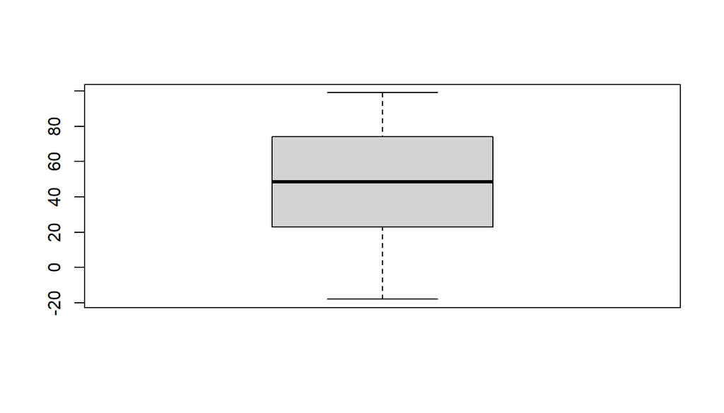

```r
boxplot(a$votes)
```

```r
df1=df1%>%
  mutate(votes=replace(votes,votes==-3,0))%>%
  mutate(votes=replace(votes,votes==-18,0))


summary(df1$votes)
```

```
##    Min. 1st Qu.  Median    Mean 3rd Qu.    Max.
##     0.0     7.0    44.0   265.1   211.0 42539.0
```

#### There are no missing values in votes column but there are outliers present in it,there are votes less than 0 which is not possible.So it is replaced by 0.

### Opentable support

```r
df1%>%
  summarise(ctnmiss=sum(is.na(opentable_support)))
```

```
##   ctnmiss
## 1      14
```

```r
df1%>%
  distinct(opentable_support)
```

```
##   opentable_support
## 1                 0
## 2                NA
```

```r
df1=df1%>%
  select(-(opentable_support))

dim(df1)
```

```
## [1] 59586    16
```

#### There is only one factor in opentable support which is not usefull for analysis so the column is removed.

### Delivery

```r
df1%>%
  summarise(ctnmiss=sum(is.na(delivery)))
```

```
##   ctnmiss
## 1       0
```

```r
df1%>%
  distinct(delivery)
```

```
##   delivery
## 1       -1
## 2        1
## 3        0
```

```r
table(df1$delivery)
```

```
##
##    -1     0     1
## 40462   344 18780
```

```r
rr=df1%>%
  filter(name=="Rasavid")%>%
  select(name,locality,delivery)

kable(rr, "html") %>% kable_styling("striped") %>% scroll_box(width = "100%")
```

| name | locality | delivery |
| --- | --- | --- |
| Rasavid | Karapakkam | 1 |
| Rasavid | Semmancheri | 1 |
| Rasavid | Thuraipakkam | 1 |
| Rasavid | Velachery | 1 |
| Rasavid | Karapakkam | 0 |
| Rasavid | Semmancheri | 0 |
| Rasavid | Thuraipakkam | 0 |

```r
df1=df1%>%
  mutate(delivery=replace(delivery,delivery==0,1))

df1=unique(df1)
dim(df1)
```

```
## [1] 59068    16
```

```r
table(df1$delivery)
```

```
##
##    -1     1
## 40119 18949
```

#### There are no missing values.There are three factors present in delivery column they are -1,0 and 1 . -1 corresponds to not deliverable whereas 0 and 1 corresponds to deliverable.On looking at the restaurants having delivery as 0,the same restaurant names also have a row with delivery as 1.So clearly the rows with 0 are duplicated.So it is replaced with 1 to avoid redundancy and to make it simple for analysis.

### Takeaway

```r
df1%>%
  summarise(ctnmiss=sum(is.na(takeaway)))
```

```
##   ctnmiss
## 1       0
```

```r
df1%>%
  distinct(takeaway)
```

```
##   takeaway
## 1       -1
```

```r
table(df1$takeaway)
```

```
##
##    -1
## 59068
```

```r
df1=df1%>%
  select(-(takeaway))

dim(df1)
```

```
## [1] 59068    15
```

#### The takeaway columns have only 1 factor which is not usefull for analysis.So it is removed.

```r
sapply(df1,function(x) sum(is.na(x)))
```

```
##                 name        establishment                 city
##                    0                    0                    0
##             locality             latitude            longitude
##                    0                    0                    0
##             cuisines average_cost_for_two          price_range
##                    0                    0                    0
##           highlights     aggregate_rating          rating_text
##                    0                    0                    0
##                votes          photo_count             delivery
##                    0                    0                    0
```

## **Overall Analysis(INDIA)**

### **(i)Univariate Analysis on India**

### Loading Useful Package

```r
pkgs <- c( "data.table","RColorBrewer", "wesanderson",
          "viridis", "ggplot2", "corrplot","dplyr","lattice","Hmisc","tidytext")

rc <- sapply(pkgs, function(x){
  library(package = x, character.only = T, logical.return = T)
}, simplify = F)
df=data.table(read.csv("zomatocleaned1.csv"))
```

## Based on City

### Cities and restaurant count

```r
#cites and their restaurant count
res_city <- dcast(df, city ~.)
```

```
## Aggregate function missing, defaulting to 'length'
```

```r
names(res_city)[1] <- "City"
names(res_city)[2] <- "Count"


res_city <- res_city[order(Count, decreasing = T)]
res_city
```

```
##              City Count
##  1:       Chennai  2608
##  2:        Mumbai  2530
##  3:     Bangalore  2365
##  4:          Pune  1911
##  5:     New Delhi  1844
##  6:        Jaipur  1456
##  7:       Kolkata  1413
##  8:     Ahmedabad  1319
##  9:       Lucknow  1283
## 10:           Goa  1168
## 11:        Nagpur  1102
## 12:        Indore  1093
## 13:         Kochi  1020
## 14:    Coimbatore  1014
```

[output cut: 86 more lines]

#### **INFERENCE:**From the table we can see that Chennai city has the highest number of restaurants followed by Mumbai,Bangalore,Pune and others.

### Barplot on cities having more than 800 restaurants.

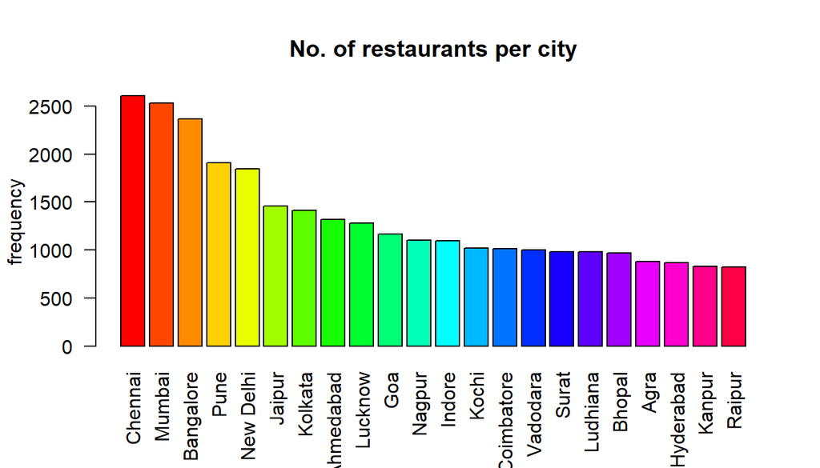

```r
a=res_city%>%
  filter(Count>800)


barplot(height = a$Count, names.arg = a$City,
        col = rainbow(length(a$City)), main = "No. of restaurants per city",
         ylab = "frequency", las = 2)
```

#### **INFERENCE:**There are 22 cities having restaurants more than 800.Chennai,Mumbai and Bangalore have more than 2000 restaurants.

## Based on Establishment

### Barplot on number of restaurants by establishment type

```r
b=df%>%
  group_by(establishment)%>%
  summarise(Count=n())%>%
  arrange(desc(Count))
```

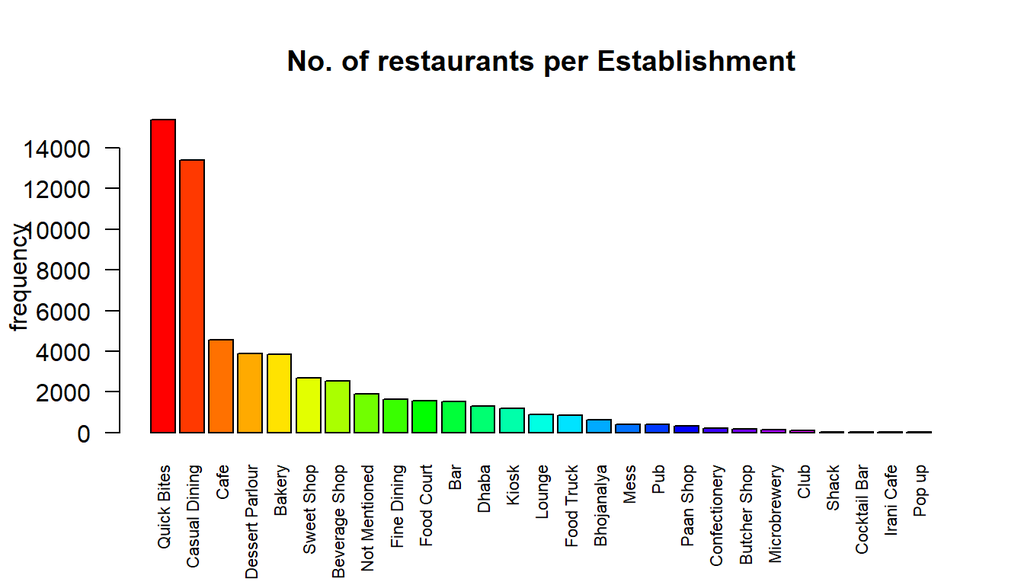

```r
barplot(height = b$Count, names.arg = b$establishment ,
        col = rainbow(n = length(b$establishment)),
        main = "No. of restaurants per Establishment"
        , ylab = "frequency", las = 2,cex.names = 0.7)
```

#### **INFERENCE:**From the barplot we can see that most of the restaurants in india are established as Quick Bites,Casual Dining.The least established types are shack,Cocktail Bar,Irani Cafe,Pop up.

## Based on Rating text

### No of restaurants by rating text

```r
cd=df%>%
  group_by(rating_text)%>%
  summarise(con=n())%>%
  arrange(desc(con))
```

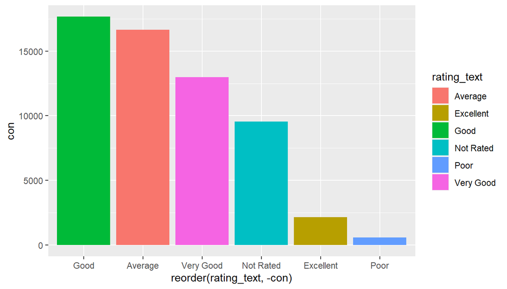

```r
ggplot(data=cd,mapping=aes(x=reorder(rating_text,-con),y=con))+geom_bar(stat = "identity",aes(fill=rating_text))
```

### Restaurants based on the ratings and city wise

```r
db=dcast(df,city~rating_text)
```

```
## Aggregate function missing, defaulting to 'length'
```

```r
db
```

```
##              city Average Excellent Good Not Rated Poor Very Good
##  1:          Agra     255        15  265       197    7       140
##  2:     Ahmedabad     272        71  423       161   12       380
##  3:         Ajmer     155        10  132        99    0        68
##  4:     Alappuzha       7         0   30       228    0         2
##  5:     Allahabad     203         7  162       116    0        72
##  6:      Amravati     117         4   93       174    1        31
##  7:      Amritsar     249        11  196       100    2       124
##  8:    Aurangabad     229        12  200       136    4       111
##  9:     Bangalore     225       242  547       139   52      1160
## 10:        Bhopal     305        28  282       174    9       169
## 11:  Bhubaneshwar     256        20  244       102    1       158
## 12:    Chandigarh     188        36  235        35    8       179
## 13:       Chennai     436       166  997        97   37       875
## 14:    Coimbatore     310        21  298       205    6       174
```

[output cut: 86 more lines]

## Based on Aggregate ratings

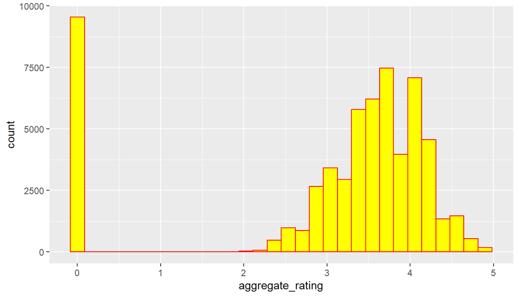

```r
ggplot(df, aes(x = aggregate_rating)) + geom_histogram(col = "red", fill = "yellow")
```

#### **INFERENCE:** We can see from the histogram that many of the restaurants have aggregate rating as 0 which means these restaurants are not rated.Hence we will plot the histogram only for restaurants that are rated by the customers.

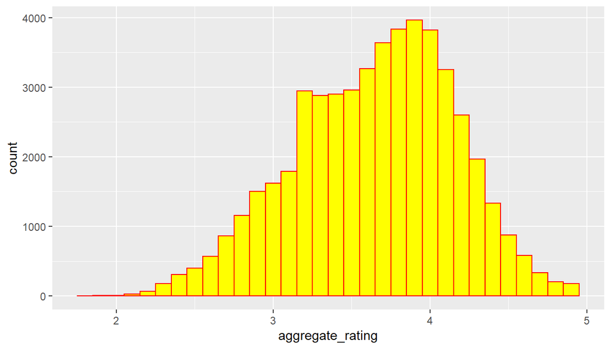

```r
df1=df%>%
  filter(aggregate_rating!=0)

ggplot(df1, aes(x = aggregate_rating)) + geom_histogram(col = "red", fill = "yellow",bins=32)
```

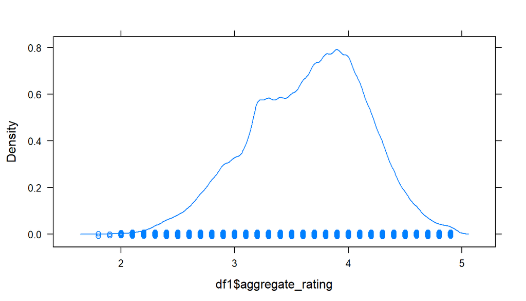

```r
densityplot(df1$aggregate_rating)
```

## Based on price range

### Barplot on number of restaurants based on price range

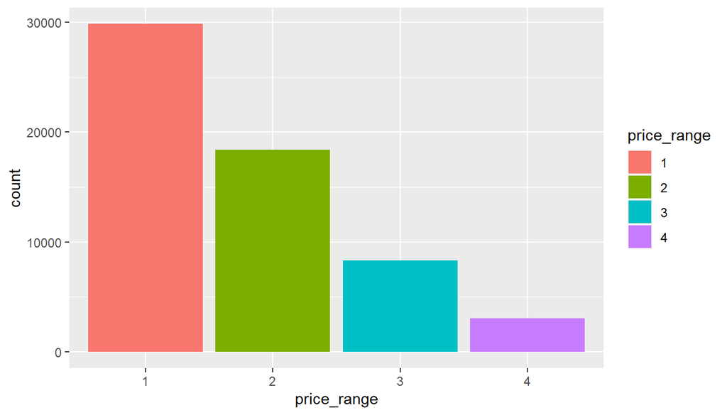

```r
df$price_range=as.factor(df$price_range)
ggplot(df,aes(x=price_range))+geom_bar(aes(fill=price_range))
```

#### **INFERENCE:**Most of the restaurants are present in price range 1 which corresponds to cheap followed by 2,3 and 4 which corresponds to costly.

### Pie chart on price range distribution

```r
f=table(df$price_range)
f=as.data.frame.table(f)
f
```

```
##   Var1  Freq
## 1    1 29829
## 2    2 18372
## 3    3  8295
## 4    4  3058
```

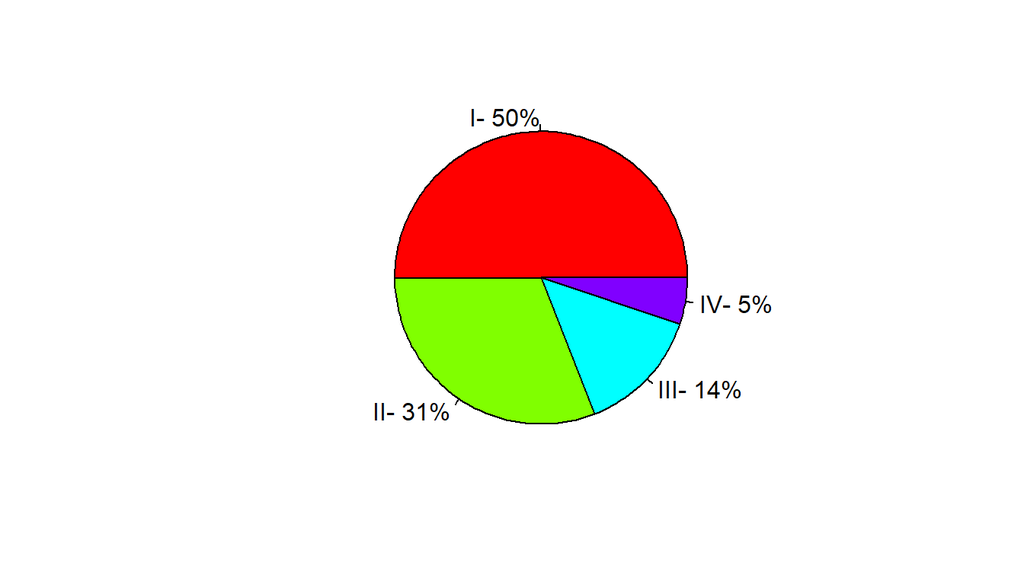

```r
lbls=c("I-","II-","III-","IV-")
pct=round(f$Freq/sum(f$Freq)*100)
lbls=paste(lbls,pct)
lbls=paste(lbls,"%",sep="")
pie(f$Freq,labels = lbls,col = rainbow(length(f$Var1)),radius =1 )
```

#### **INFERENCE:**We can see that 50% of the restaurants are in the price range 1.

### Delivery

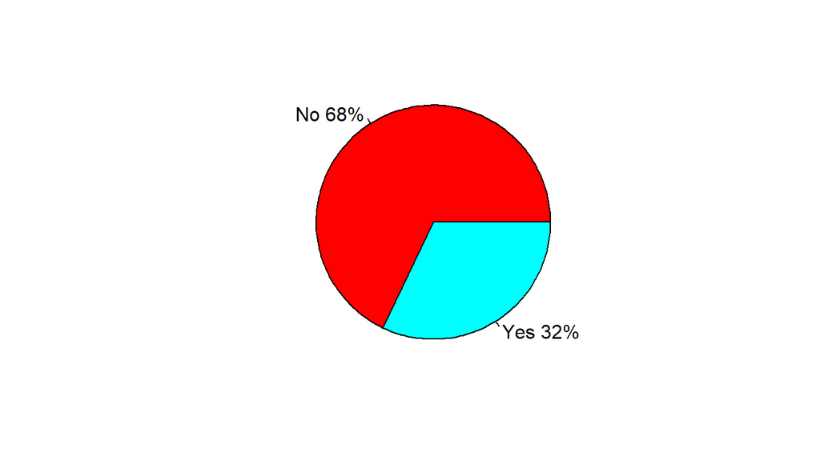

```r
#Delivery
g=table(df$delivery)
g=as.data.frame.table(g)

lbls=c("No","Yes")
pct=round(g$Freq/sum(g$Freq)*100)
lbls=paste(lbls,pct)
lbls=paste(lbls,"%",sep="")

pie(g$Freq,labels=lbls,col=rainbow(length(g$Var1)),radius =1 )
```

#### **INFERENCE:**We can see that majority of the restaurants do not have delivery option.

## Based on Average cost for two

### Frequency distribution on average cost for two.

```r
res=dcast(df, cut2(df$average_cost_for_two, g = 20)~.)
```

```
## Aggregate function missing, defaulting to 'length'
```

```r
names(res) <- c("cost_for_two_bin", "count")
which.min(res$count)
```

```
## [1] 9
```

```r
res
```

```
##     cost_for_two_bin count
##  1:     [   2,  110)  5182
##  2:     [ 110,  160)  4136
##  3:     [ 160,  208)  7076
##  4:     [ 208,  260)  3757
##  5:     [ 260,  309)  6967
##  6:     [ 309,  404)  7824
##  7:     [ 404,  470)  1367
##  8:     [ 470,  505)  5267
##  9:     [ 505,  592)   578
## 10:     [ 592,  620)  3040
## 11:     [ 620,  800)  2794
## 12:     [ 800,  940)  2947
## 13:     [ 940, 1230)  3334
## 14:     [1230, 1650)  2557
## 15:     [1650,30000]  2728
```

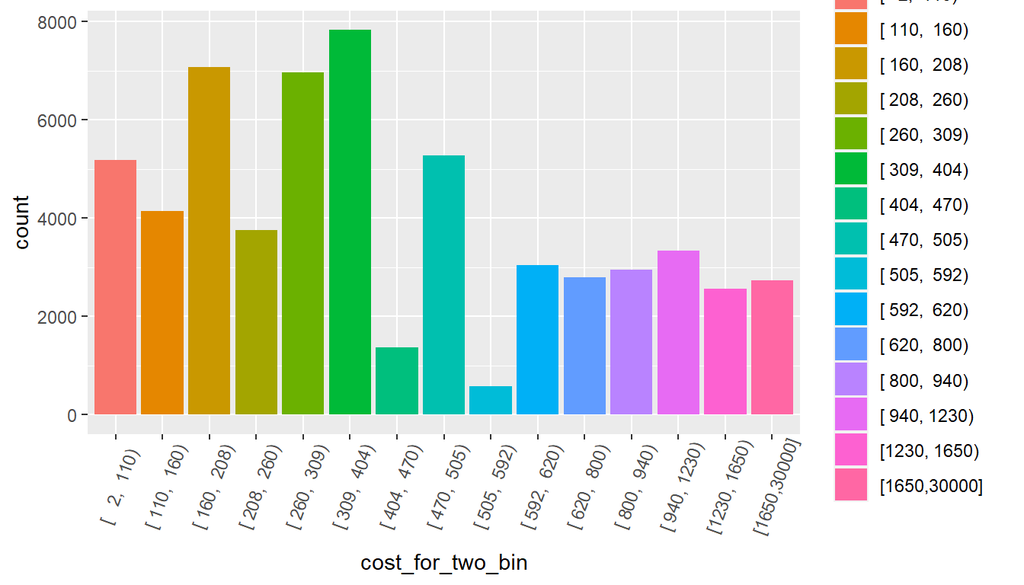

```r
ggplot(data=res,mapping=aes(x=cost_for_two_bin,y=count,fill=cost_for_two_bin))+geom_bar(stat = "identity")+theme(axis.text.x = element_text(angle = 70, vjust = .6))
```

#### **INFERENCE:** Based on the plot we can see that restaurants with the price range of 309 to 404 have the highest count followed by restaurants with price range of 160 to 208 and so on.Restaurants with price range 505 to 592 have the least number of restaurants

## Based on Cuisines

### Top 5 cuisines in India

```r
library(tidytext)

a=df%>%
  select(cuisines)
a[1,]
```

```
##                                                     cuisines
## 1: North Indian, South Indian, Mithai, Street Food, Desserts
```

```r
p=df%>%
  select(cuisines)%>%
  unique()%>%
  mutate(cuisines=as.character(cuisines))%>%
  unnest_tokens(ngram,cuisines,token = 'ngrams',n=2)%>%
  group_by(ngram)%>%
  summarise(n=n())%>%
  arrange(desc(n))%>%
  top_n(5)
```

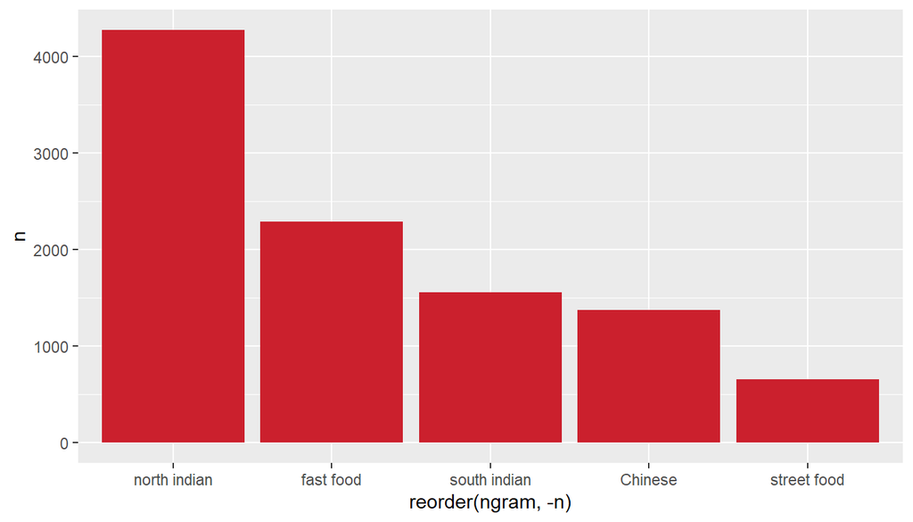

```r
p$ngram[4]="Chinese"

ggplot(p,aes(x=reorder(ngram,-n),y=n))+geom_bar(stat='identity',fill='#cb202d')
```

#### **INFERENCE:** Majority of the restaurants have north Indian Cuisine followed by fast food ,South Indian,Chinese and Street food.

## Based on Highlights

### Top 10 Highlights

```r
rw=df%>%
  select(highlights)%>%
  unique()%>%
  mutate(highlights=as.character(highlights))%>%
  unnest_tokens(ngram,highlights,token = 'ngrams',n=2)%>%
  group_by(ngram)%>%
  summarise(n=n())%>%
  arrange(desc(n))%>%
  top_n(10)
rw
```

```
## # A tibble: 10 x 2
##    ngram                  n
##    <chr>              <int>
##  1 takeaway available 25451
##  2 indoor seating     24423
##  3 credit card        20994
##  4 debit card         19223
##  5 air conditioned    17779
##  6 alcohol available  10201
##  7 no alcohol         10201
##  8 digital payments    9793
##  9 payments accepted   9793
## 10 pure veg            9109
```

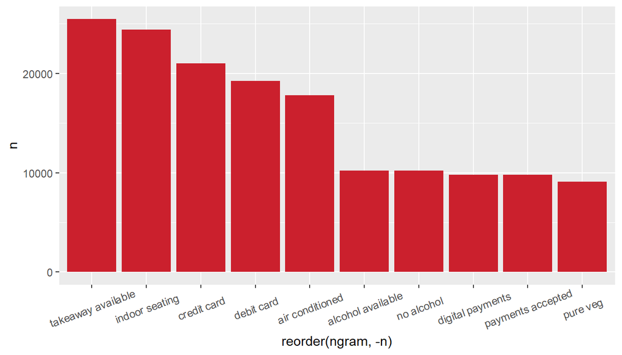

```r
ggplot(rw,aes(x=reorder(ngram,-n),y=n))+geom_bar(stat='identity',fill='#cb202d')+
  theme(axis.text.x = element_text(angle = 20, vjust = .6))
```

#### **INFERENCE:**Majority of the restaurants higlights are about takeaway availability,indoor seating,credit card,debit card,AC and so on.

## **(ii)Geo spatial analysis**:

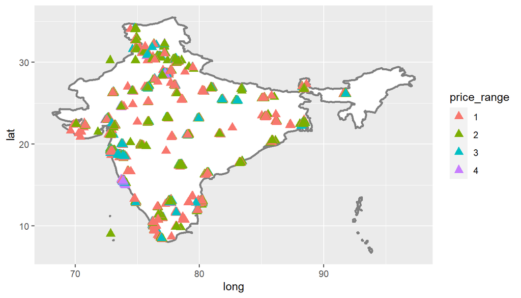

```r
#latitude and longitude
library(maps)
library(ggmap)
library(ggridges)

ll=read.csv("zomatocleanedwithlatandlong.csv")

ll=ll%>%
  filter(longitude>67&longitude<98&latitude>8 &latitude<38)

indiamap=map_data("world")
indiamap=indiamap%>%filter(region=="India")
indiamap=fortify(indiamap)
zomat=ll%>%select(latitude,longitude,price_range)%>%
  mutate(price_range=as.factor(price_range))
p=ggplot()
p=p+geom_map(data=indiamap,map=indiamap,aes(x=long,y=lat,group=group,map_id=region),fill="white", colour="#7f7f7f", size=1)
p=p+geom_point(data=zomat,aes(x=longitude,y=latitude,colour=price_range),size=3,shape=17)
p
```

#### **INFERENCE:** We can see that most of the points represents restaurants with price range 1 and price range 2.Cities like Chennai,Kochi,Mumbai,Kolkata,Pune show some restaurants with price range 3.Cities like Goa,New Delhi show some restaurants with price range 4

## **Analysis on restaurants in Chennai**

### **(iii)Univariate Analysis on Chennai**:

```r
remove(df)

df=data.table(read.csv("zomatocleaned1.csv"))

df$establishment=as.factor(df$establishment)
df$city=as.factor(df$city)
df$price_range=as.factor(df$price_range)

df$rating_text=as.factor(df$rating_text)
df$delivery=as.factor(df$delivery)


df1=df%>%
  filter(city=="Chennai")
```

## Based on Establishment

### Number of restaurants based on establishment

```r
b=df1%>%
  group_by(establishment)%>%
  summarise(Count=n())%>%
  arrange(desc(Count))
```

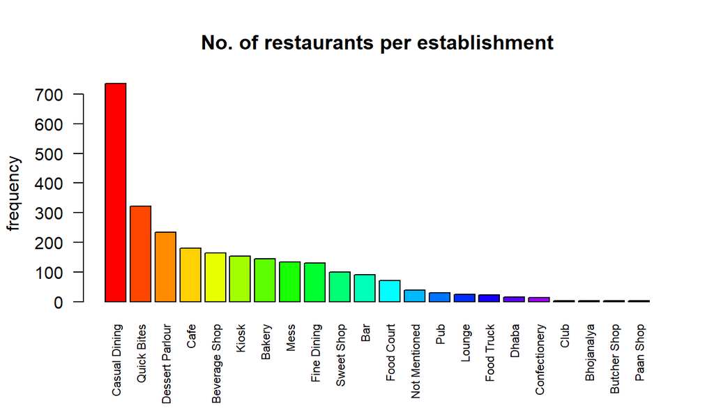

```r
barplot(height = b$Count, names.arg = b$establishment ,
        col = rainbow(n = length(b$establishment)),
        main = "No. of restaurants per establishment"
        , ylab = "frequency", las = 2,cex.names = 0.7)
```

#### **INFERENCE:** From the barplot we can see that there are a lot of restaurants established as Casual Dining followed by Quick Bites,Dessert Parlour,Cafe and so on.

## Based on Locality

### Top 15 localities in Chennai based on number of restaurants.

```r
c=df1%>%
  group_by(locality)%>%
  summarise(Count=n())%>%
  arrange(desc(Count))%>%
  top_n(15)
```

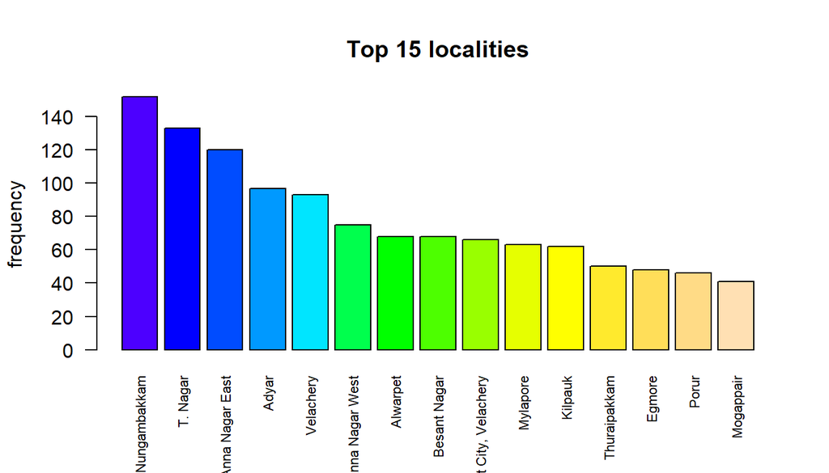

```r
barplot(height = c$Count, names.arg = c$locality ,
        col = topo.colors(n =15),
        main = "Top 15 localities"
        , ylab = "frequency", las = 2,cex.names = 0.7)
```

#### **INFERENCE:** Nungambakkam has the highest number of restaurants followed by T.Nagar,Anna Nagar East,Adyar and so on.

## Based on average cost for two:

### Frequency distribution on average cost for two.

```r
res=suppressMessages(dcast(df1, cut2(df1$average_cost_for_two, g = 10)~.,value.var = "average_cost_for_two"))
names(res) <- c("cost_for_two_bin", "count")
res
```

```
##     cost_for_two_bin count
##  1:      [  40, 250)   472
##  2:              250   103
##  3:              300   234
##  4:      [ 330, 450)   365
##  5:      [ 450, 550)   313
##  6:      [ 550, 650)   140
##  7:      [ 650, 850)   318
##  8:      [ 850,1100)   171
##  9:      [1100,1600)   264
## 10:      [1600,5500]   228
```

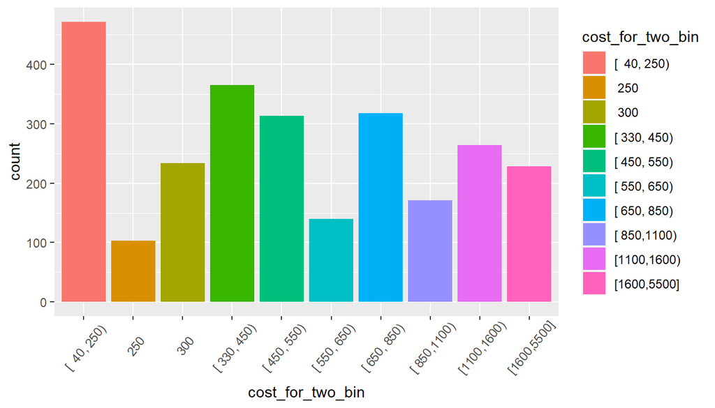

```r
ggplot(data=res,mapping=aes(x=cost_for_two_bin,y=count,fill=cost_for_two_bin))+geom_bar(stat = "identity")+theme(axis.text.x = element_text(angle = 50, vjust = .6))
```

#### **INFERENCE:** Restaurants with average cost from 40 to 250 are high in number followed by 330 to 450 ,650 to 850 and so on.

### Boxplot on the cost:

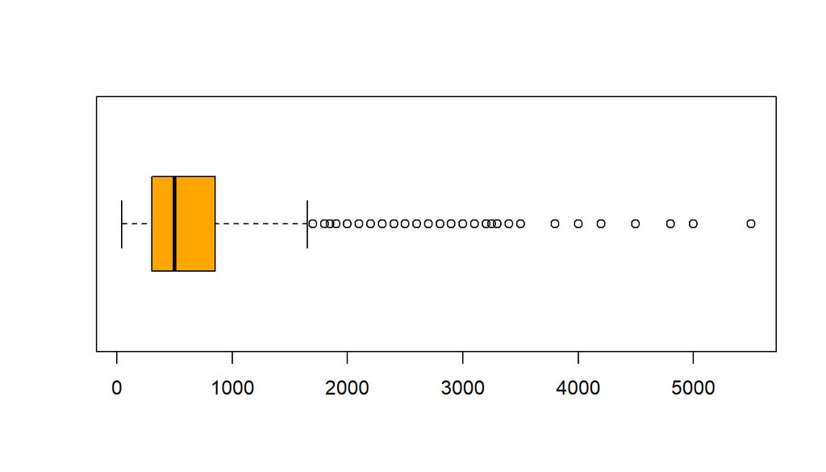

```r
boxplot(df1$average_cost_for_two,horizontal = T,col = "orange")
```

```r
summary(df1$average_cost_for_two)
```

```
##    Min. 1st Qu.  Median    Mean 3rd Qu.    Max.
##    40.0   300.0   500.0   708.3   850.0  5500.0
```

#### **INFERENCE:**Most of the costs are around the range of 300 to 850.

## Based on Aggregate rating

### Box plot on aggregate ratings

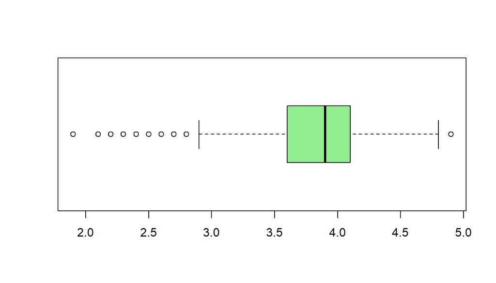

```r
df2=df1%>%
  filter(aggregate_rating!=0)
boxplot(df2$aggregate_rating,horizontal = T,col="lightgreen")
```

```r
summary(df2$aggregate_rating)
```

```
##    Min. 1st Qu.  Median    Mean 3rd Qu.    Max.
##    1.90    3.60    3.90    3.81    4.10    4.90
```

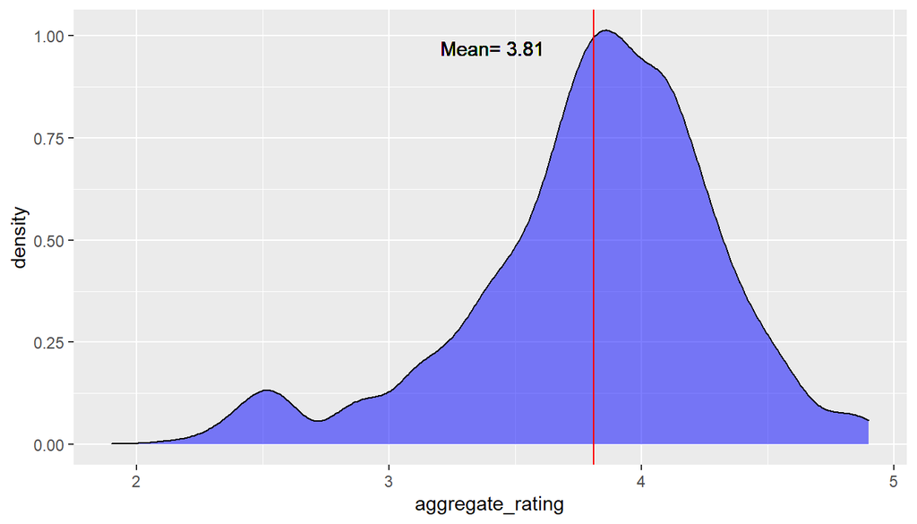

```r
df2=df1%>%
  filter(aggregate_rating!=0)

a=mean(df2$aggregate_rating)
a=round(a,2)
df2%>%
  ggplot(aes(x=aggregate_rating))+
  geom_density(fill="blue",alpha=0.5)+
  geom_vline(xintercept=a,color="red")+
  geom_text(aes(x=a-0.4),label=paste0("Mean= ",a),y=0.97)
```

#### **INFERENCE:** Most of the ratings are around 3.6 to 4.2

## Based on Cuisine

### Top 5 cuisines in Chennai

```r
p1=df1%>%
  select(cuisines)%>%
  unique()%>%
  mutate(cuisines=as.character(cuisines))%>%
  unnest_tokens(ngram,cuisines,token = 'ngrams',n=2)%>%
  group_by(ngram)%>%
  summarise(n=n())%>%
  arrange(desc(n))
p1=p1[-c(5,7,8,9),]
p=p1%>%
  top_n(5)
```

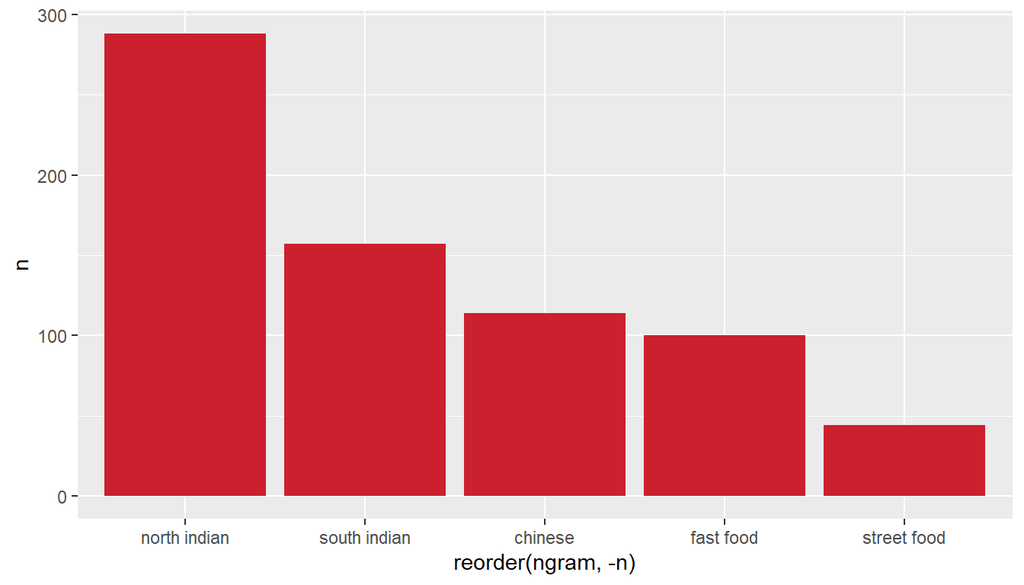

```r
p[3,1]="chinese"

ggplot(p,aes(x=reorder(ngram,-n),y=n))+geom_bar(stat='identity',fill='#cb202d')
```

#### **INFERENCE:** Majority of the restaurants have north Indian Cuisine followed by South Indian,Chinese ,fast food and Street food.

### Word Cloud on Cuisine types

```r
library(wordcloud2)
wordcloud2(p1)
```

[interactive chart not shown]

## Based on Highlights

### Top 10 highlights

```r
rw1=df1%>%
  select(highlights)%>%
  unique()%>%
  mutate(highlights=as.character(highlights))%>%
  unnest_tokens(ngram,highlights,token = 'ngrams',n=2)%>%
  group_by(ngram)%>%
  summarise(n=n())%>%
  arrange(desc(n))
rw=rw1%>%
  top_n(10)
```

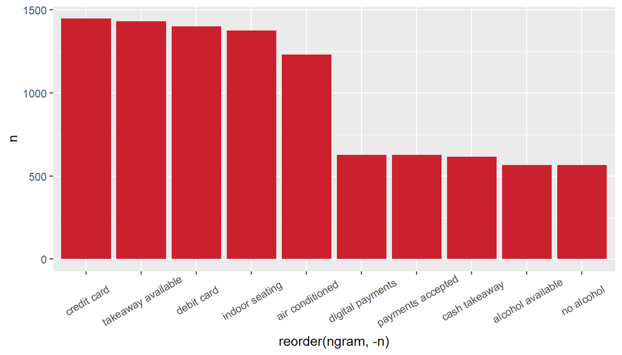

```r
ggplot(rw,aes(x=reorder(ngram,-n),y=n))+geom_bar(stat='identity',fill='#cb202d')+theme(axis.text.x = element_text(angle = 30, vjust = .6))
```

```r
rw2=rw1[1:75,]
wordcloud2(rw2)
```

[interactive chart not shown]

## Based on Rating text

### Number of restaurants by rating text

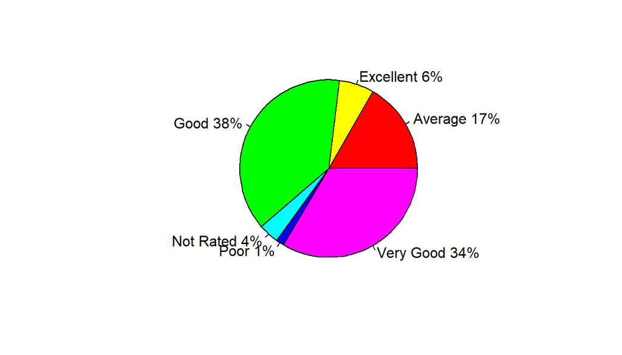

```r
x=table(df1$rating_text)
x=as.data.frame.table(x)
lbls=c("Average","Excellent","Good","Not Rated","Poor","Very Good")
pct=round(x$Freq/sum(x$Freq)*100)
lbls=paste(lbls,pct)
lbls=paste(lbls,"%",sep="")
pie(x$Freq,labels=lbls,col=rainbow(length(x$Var1)),radius =1 )
```

#### **INFERENCE:**Majority of the restaurants have Good ,Very Good and Average rating

### **(iv)Bivariate analysis on Chennai:**

### Number of restaurants based on locailty and establishment

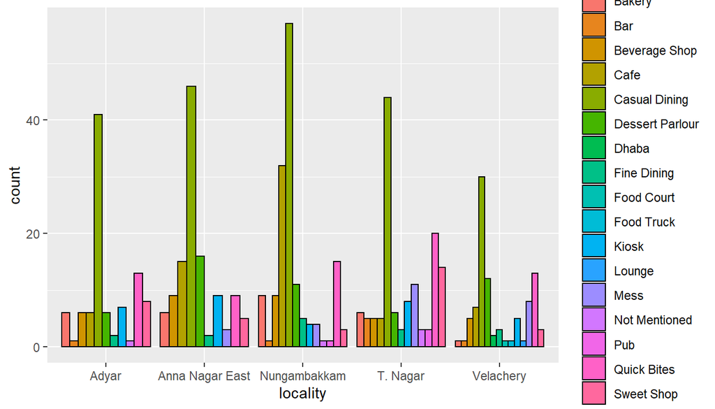

```r
df2=df1%>%
  filter(locality=="Nungambakkam"|locality=="T. Nagar"|locality=="Anna Nagar East"|locality=="Adyar"|locality=="Velachery")


bp=ggplot(data = df2) +
  geom_bar(mapping = aes(x = locality, fill = establishment),colour="black", position = "dodge")

bp
```

#### **INFERENCE:** Analysis is done based on the top 5 localities in Chennai,All the localities have Casual dining restaurants high in number.Followed by that,Nungambakkam has Cafe in 2nd place.Whereas Anna Nagar East has Dessert parlour in 2nd place .T Nagar,Velachery and Adyar have Quick Bites in 2nd place.In 3rd place T nagar,Adyar has Sweet Shop.Anna Nagar East has cafe.Nungamabakkam has quick bites.Velachery has Desert Parlour.Bars and Pubs were the least in all of the locality.

### locality and price range

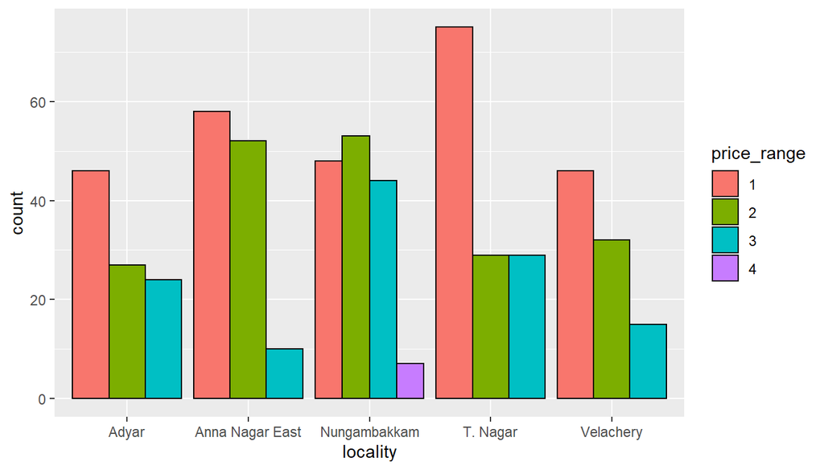

```r
ggplot(data = df2) +
  geom_bar(mapping = aes(x = locality, fill = price_range),colour="black", position = "dodge")
```

#### **INFERENCE:**T.Nagar,Velachery,Anna Nagar East and Adyar have restaurants with price range “1” in high numbers followed by price range 2 and 3.Nungambakkam has price range “2” in the 1st place followed by price range “1”,“3” and “4”.From the 5 localities only Nungambakkam has restaurants with price range “4”

### LOCALITY AND REVIEWS

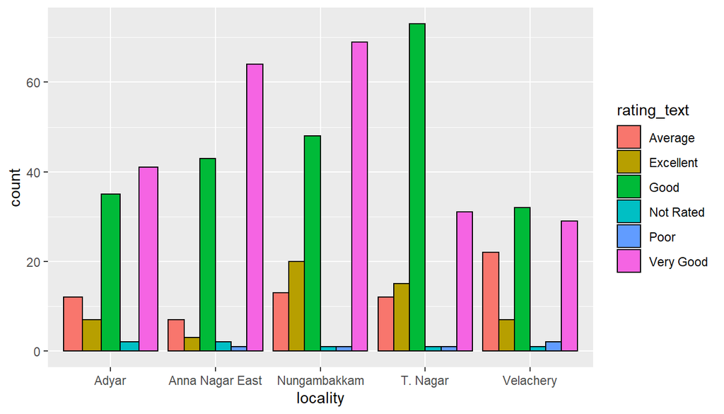

```r
bp=ggplot(data = df2) +
  geom_bar(mapping = aes(x = locality, fill = rating_text),colour="black", position = "dodge")
bp
```

#### **INFERENCE:** From the top 5 localities in Chennai.Adyar,Anna Nagar East and Nungambakkam have restaurants with rating “Very Good” in 1 st place.Whereas T.Nagar and Velachery have restaurants with rating “Good” in 1 st place.We can see that quality of restaurants in T.Nagar and Velachery is less compared to Adyar,Anna Nagar East and Nungambakkam.In 2nd place,Adyar ,Anna Nagar East and Nungambakkam have restaurants with rating “Good”.T.Nagar and Velachery have restaurants with rating “Very good” in 2nd place.In the 3rd place Adyar,Anna Nagar East and Velachery have restaurants with rating “Average”.Nungambakkam and T.Nagar have restaurants with rating “Excellent”.All the locality have restaurants with “poor” rating low.

### Top 10 localities having restaurants with the least average cost

```r
b=df1%>%
  group_by(locality)%>%
  summarise(avgprice=mean(average_cost_for_two))%>%
  arrange(desc(-avgprice))%>%head(n=10)
b[2,1]="Thuraipakkam"
b[10,1]="Guduvancheri"
b
```

```
## # A tibble: 10 x 2
##    locality      avgprice
##    <chr>            <dbl>
##  1 Kelambakkam         80
##  2 Thuraipakkam       150
##  3 Vepery             175
##  4 Abhiramapuram      200
##  5 Koyambedu          200
##  6 Madhavaram         200
##  7 Mandaveli          200
##  8 Thiruvallur        200
##  9 Chengalpattu       225
## 10 Guduvancheri       225
```

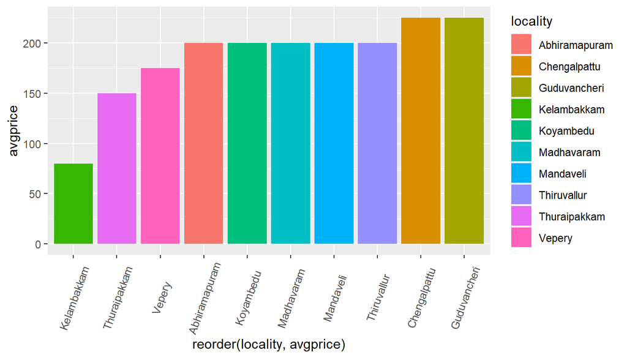

```r
b%>%ggplot(aes(x=reorder(locality,avgprice),y=avgprice,fill=locality))+
  geom_bar(stat="identity")+
  theme(axis.text.x = element_text(angle = 70, vjust = .5))
```

#### **INFERENCE:** Kelambakkam has restaurants with the overall average cost to be 80.Hence most of the restaurants in this locality provides the cheapest in the city.

### Restaurant count based on Cuisine

```r
p=df2%>%
  select(cuisines,locality)%>%
  unique()%>%
  mutate(cuisines=as.character(cuisines))%>%
  unnest_tokens(ngram,cuisines,token = 'ngrams',n=2)%>%
  group_by(ngram,locality)%>%
  summarise(n=n())%>%
  arrange(desc(n))
```

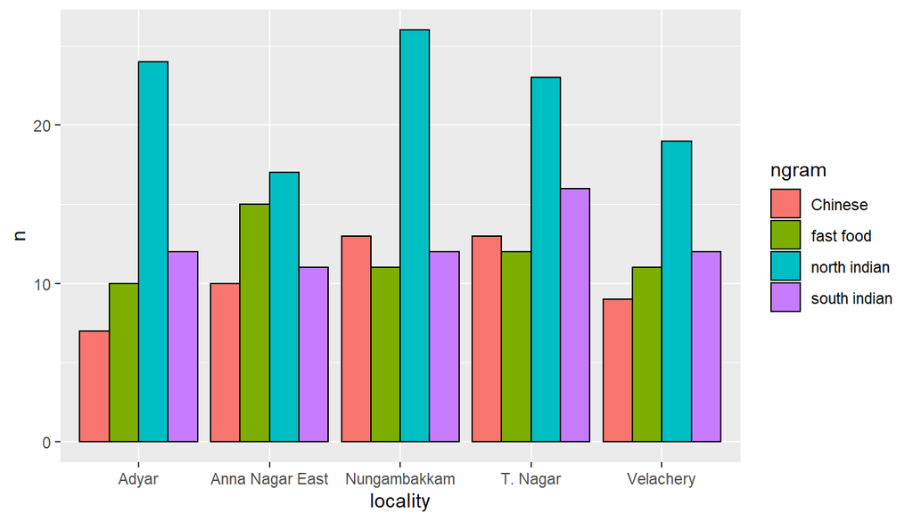

```r
w=head(p,n=24)


w=w[-c(21,23,19,24),]

w=w%>%
  mutate(ngram=replace(ngram,ngram=="indian chinese","Chinese"))
ggplot(data = w) +
  geom_bar(mapping = aes(x = locality,y=n, fill = ngram),colour="black",position = "dodge",stat = "identity")
```

#### **INFERENCE:** All the top 5 localities have restaurants providing “North Indian” cuisine in 1 st place.In the 2nd place Adyar,T.Nagar and Velachery have restaurants providing “South Indian” Cuisine .Anna Nagar East has restaurants providing “fast food” Cuisine and Nungambakkam has restaurants providing “Chinese” Cuisine.In 3rd place,Adyar and Velachery has restaurants providing “fastfood”,Anna Nagar East and Nungambakkam have south indian cuisine,T.Nagar has chinese cusine.

### Restaurant count based on establishment and price range

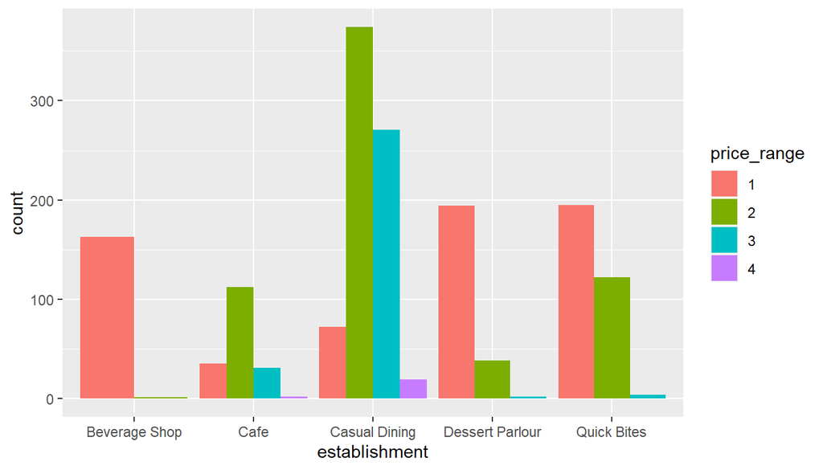

```r
df1$price_range=as.factor(df1$price_range)

df2=df1%>%
  filter(establishment=="Casual Dining"|establishment=="Quick Bites"|establishment=="Dessert Parlour"|establishment=="Cafe"|establishment=="Beverage Shop")

ggplot(data = df2) +
  geom_bar(mapping = aes(x = establishment, fill = price_range),position = "dodge")
```

#### **INFERENCE:** Most of the beverage shop have a price range of 1 with very few having price range 2.Most of Cafe’s have price range of 2 followed by 1,3 and 4.Most of the casual Dinings have price range 2 followed by 3,1 and 4.Most of the Desserts Parlour and Quick Bites have price range 1 followed by 2 and 3.

### Top establishments and their aggregate ratings

```r
df2=df1%>%
  filter(establishment=="Casual Dining"|establishment=="Quick Bites"|establishment=="Dessert Parlour"|establishment=="Cafe"|establishment=="Beverage Shop")
df2$establishment=factor(df2$establishment)

df2=df2%>%
  filter(aggregate_rating!=0)

df2%>%
  group_by(establishment)%>%
  summarise(median=median(aggregate_rating),mean=mean(aggregate_rating),minimum=min(aggregate_rating),maximum=max(aggregate_rating))
```

```
## # A tibble: 5 x 5
##   establishment   median  mean minimum maximum
##   <fct>            <dbl> <dbl>   <dbl>   <dbl>
## 1 Beverage Shop      3.8  3.83     3.1     4.6
## 2 Cafe               4    3.96     2.3     4.6
## 3 Casual Dining      4.1  3.93     1.9     4.9
## 4 Dessert Parlour    3.9  3.85     2.4     4.6
## 5 Quick Bites        3.9  3.81     2.2     4.8
```

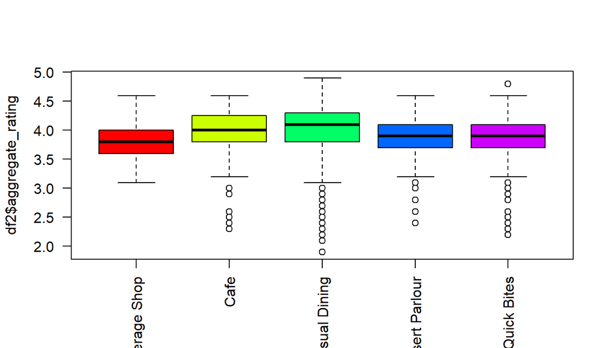

```r
boxplot(df2$aggregate_rating~df2$establishment,las=2,xlab = "",col=rainbow(length(unique(df2$establishment))))
```

### Relationship between aggregate ratings and price range

```r
a=df1%>%
  filter(aggregate_rating!=0)

a%>%
  group_by(price_range)%>%
  summarise(median=median(aggregate_rating),mean=mean(aggregate_rating),minimum=min(aggregate_rating),maximum=max(aggregate_rating))
```

```
## # A tibble: 4 x 5
##   price_range median  mean minimum maximum
##   <fct>        <dbl> <dbl>   <dbl>   <dbl>
## 1 1              3.7  3.69     2.2     4.8
## 2 2              3.9  3.77     1.9     4.9
## 3 3              4.1  4.10     2.5     4.9
## 4 4              4.1  4.06     2.7     4.8
```

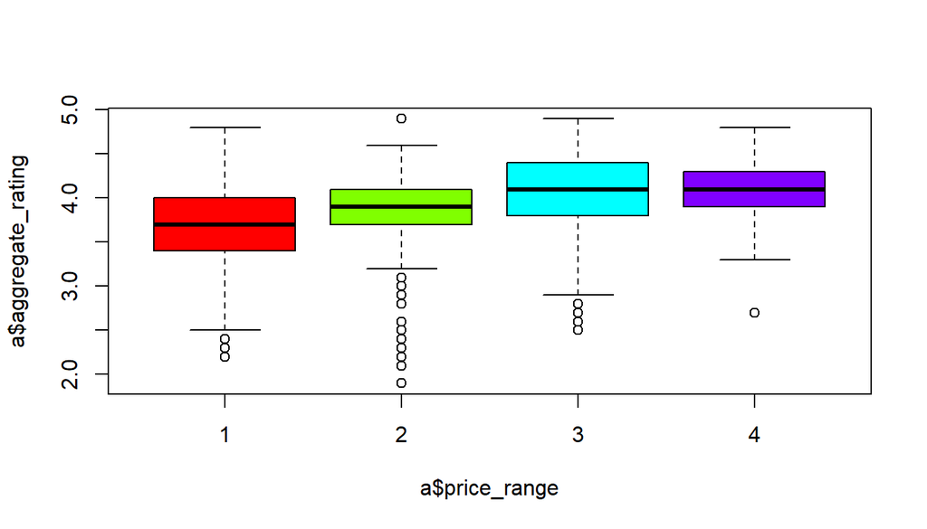

```r
boxplot(a$aggregate_rating~a$price_range,col=rainbow(length(unique(a$price_range))))
```

#### **INFERENCE:** As the price range increases the aggregate ratings also tends to increase